# **Modeling Notebook**

**Authors: Nick Sarka, Alex Hamill, Nick Goshev, Matt Johnescu, Carson Hansen**

# Table of Contents:

- Introduction
- Importing Packages
- Loading Data
- Unsupervised Learning
  - MiniBatchKMeans and PCA
  - Unplanned Clustering
  - Planned Clustering
  - Clustering Results
  - Association Rule Mining
- Supervised Learning
  - Supervised Model Data Cleaning
  - Linear Regression
  - Lasso Regression
  - Dummy Regression
  - Random Forest
  - Supervised Models Results
    - Costs Interpretation

# Introduction

**Overview of Production Challenges:**

Swire Coca-Cola produces close to 192 million cases of beverages annually across six production plants, but unplanned equipment breakdowns currently reduce production efficiency to 94.4% of the demand. This gap leads to nearly $60 million in annual losses due to downtime. To bridge this gap, we embarked on a predictive maintenance project to analyze historical maintenance data, identify patterns, and predict when equipment failures may occur. These insights provide a basis for developing proactive maintenance strategies that may mitigate costly disruptions and enhance overall operational efficiency.

**Approach to Analyzing Maintenance Data:**

This project involves using both unsupervised and supervised learning techniques to gain a deeper understanding of maintenance patterns and factors contributing to downtime.

**Unsupervised Learning Models:**

**Supervised learning models:**

Supervised learning models, including linear regression, lasso regression, and random forest, were applied to quantify the impact of different features on maintenance duration. Linear regression provided an overall understanding, whereas lasso regression highlighted specific features that significantly influenced downtime. For instance, maintenance activities involving filler and palletizer equipment were found to have the highest positive impact on maintenance time, indicating inefficiencies and potential areas for improvement. The lasso model allowed us to identify the top ten features contributing to increased maintenance duration and those that helped reduce it, providing clear guidance on which factors to address.

A key finding from the lasso model was that certain proactive maintenance tasks, such as daily line support activities, had a significant negative coefficient, indicating that they effectively reduced maintenance time. In contrast, unplanned corrective actions related to specific equipment, like palletizers and packers, were associated with increased maintenance durations. The random forest model further improved predictive accuracy by capturing complex interactions between variables, allowing us to understand the broader impact of maintenance practices across different production lines.

**Implementation of Predictive Maintenance Strategy:**

By integrating these insights, Swire Coca-Cola could implement a predictive maintenance pipeline that minimizes unplanned downtime, targets high-impact areas for efficiency improvements, and ensures the timely availability of spare parts. This proactive strategy will ultimately enable Swire Coca-Cola to enhance production reliability, meet demand more effectively, and achieve significant cost savings by reducing the frequency and duration of equipment breakdowns.

# Importing Packages

```python
import pandas as pd
import numpy as np
import os
import matplotlib.pyplot as plt
import seaborn as sns
from math import sqrt
from sklearn.linear_model import Lasso
from sklearn.ensemble import RandomForestRegressor
from sklearn.model_selection import train_test_split
from sklearn.metrics import mean_squared_error, r2_score, mean_absolute_error
from sklearn.preprocessing import StandardScaler, OneHotEncoder
from sklearn.compose import ColumnTransformer
from sklearn.pipeline import Pipeline
from google.colab import drive, auth
from sklearn.dummy import DummyRegressor
from google.colab import drive
from google.colab import auth
from sklearn.ensemble import RandomForestRegressor
from sklearn.model_selection import train_test_split
from sklearn.preprocessing import LabelEncoder
from sklearn.preprocessing import StandardScaler
from sklearn.decomposition import PCA
from sklearn.cluster import MiniBatchKMeans
from mlxtend.preprocessing import TransactionEncoder
from mlxtend.frequent_patterns import apriori, association_rules

# Mount Google Drive
drive.mount('/content/drive')

import warnings
warnings.filterwarnings('ignore')
```

# Loading Data

```python
master_df = pd.read_csv('IWC_Work_Orders_Extract.csv')

# GROUP 2: Nick S., Nick G.
master_df2 = master_df.copy()
```

# Unsupervised Learning

### Cleaning the data

Unsupervised algorithms like clustering perform better on homogeneous data Splitting the data can reduce variability caused by mixing different maintenance types.

```python
columns_to_remove = ['ORDER_ID', 'FUNCTIONAL_AREA_NODE_1_MODIFIED',
                    'FUNCTIONAL_AREA_NODE_2_MODIFIED', 'FUNCTIONAL_AREA_NODE_3_MODIFIED',
                    'FUNCTIONAL_AREA_NODE_4_MODIFIED', 'FUNCTIONAL_AREA_NODE_5_MODIFIED',
                     'EQUIP_VALID_TO', 'PRODUCTION_LOCATION']

master_df2 = master_df2.drop(columns=columns_to_remove, axis=1)
```

```python
columns_to_fill = ['MAINTENANCE_PLAN', 'MAINTENANCE_ITEM', 'FUNCTIONAL_LOC', 'EQUIPMENT_DESC', 'EQUIP_CAT_DESC',
                  'EQUIP_START_UP_DATE', 'EQUIP_VALID_FROM', 'EQUIPMENT_ID']
master_df2[columns_to_fill] = master_df[columns_to_fill].fillna('Unknown')
```

### MiniBatchKMeans and PCA

```python
MiniPCA = master_df2.copy()
```

```python
columns_to_drop = ['EXECUTION_START_DATE', 'EXECUTION_FINISH_DATE',
                   'ACTUAL_START_TIME', 'ACTUAL_FINISH_TIME', 'EQUIP_VALID_FROM',
                   'EQUIP_START_UP_DATE', 'MAINTENANCE_PLAN', 'MAINTENANCE_ITEM', 'ACTUAL_WORK_IN_MINUTES']
MiniPCA.drop(columns=columns_to_drop, inplace=True)
```

```python
# Apply one-hot encoding to 'PLANT_ID' column
MiniPCA_encoded = pd.get_dummies(MiniPCA, columns=['PLANT_ID'], drop_first=True)

# Identify non-numeric columns after one-hot encoding
non_numeric_cols = MiniPCA_encoded.select_dtypes(include=['object', 'category']).columns
print("Non-numeric columns:", non_numeric_cols)

# Apply LabelEncoder only if there are non-numeric columns
if len(non_numeric_cols) > 0:
    for col in non_numeric_cols:
        le = LabelEncoder()
        MiniPCA_encoded[col] = le.fit_transform(MiniPCA_encoded[col].astype(str))
else:
    print("No non-numeric columns to encode.")
```

```
Non-numeric columns: Index(['MAINTENANCE_ACTIVITY_TYPE', 'ORDER_DESCRIPTION',
       'MAINTENANCE_TYPE_DESCRIPTION', 'FUNCTIONAL_LOC', 'EQUIPMENT_ID',
       'EQUIPMENT_DESC', 'EQUIP_CAT_DESC'],
      dtype='object')
```

```python
# Convert DataFrame to NumPy array and standardize
X = MiniPCA_encoded.values
scaler = StandardScaler()
X_scaled = scaler.fit_transform(X)

# Reduce dimensionality
pca = PCA(n_components=5, random_state=42)
X_reduced = pca.fit_transform(X_scaled)

# Apply MiniBatch KMeans
mbk10 = MiniBatchKMeans(n_clusters=10, batch_size=10000, random_state=42)
mbk10.fit(X_reduced)
labels = mbk10.labels_

MiniPCA_encoded['Cluster'] = labels  # 'labels' should be the output from mbk10.labels_
```

```python
# Group data by clusters and calculate average feature values for cluster analysis
cluster_summary = MiniPCA_encoded.groupby('Cluster').mean()

# Display the summary of the clusters
print("Cluster Summary (Average Feature Values):")
print(cluster_summary)

# Check the size of each cluster
cluster_sizes = MiniPCA_encoded['Cluster'].value_counts()
print("\nCluster Sizes:")
print(cluster_sizes)

# Highlight key insights about clusters by printing top contributing features
for cluster in cluster_summary.index:
    print(f"\nCluster {cluster} Analysis:")
    print(cluster_summary.loc[cluster].sort_values(ascending=False).head(5))  # Top 5 contributing features per cluster
```

```
Cluster Summary (Average Feature Values):
         MAINTENANCE_ACTIVITY_TYPE  ORDER_DESCRIPTION  \
Cluster
0                         0.536803       62736.675294
1                         0.999995      118906.715201
2                         0.722943       64182.655194
3                         1.000000      118896.006481
4                         0.602735       57093.540805
5                         0.914218      105780.378885
6                         0.500761       47713.540758
7                         0.212025       60515.435973
8                         1.000000      118879.201675
9                         0.998547      118889.055396

         MAINTENANCE_TYPE_DESCRIPTION  FUNCTIONAL_LOC  EQUIPMENT_ID  \
Cluster
0                            3.450787       99.517427    861.411160
1                            4.999995      667.000000   2955.999805
2                            3.004817      600.101935   2062.972108
3                            4.999056      666.803011   2955.885993
4                            3.274502      614.721835   1553.296588
5                            4.655610      617.568186   2750.922878
6                            3.391566      532.380662   1176.189352
7                            3.780713      281.774457    562.101282
8                            4.991128      666.404242   2954.381667
9                            4.998140      666.267352   2955.280441

         EQUIPMENT_DESC  EQUIP_CAT_DESC  PLANT_ID_G261  PLANT_ID_G291  \
Cluster
0            796.664462        3.993473       0.593390       0.023691
1            797.000000        4.000000       1.000000       0.000000
2            392.346360        0.003030       0.000000       0.000000
3            797.000000        4.000000       0.000000       0.000473
4            796.979327        3.997540       0.000000       0.000000
5            795.400884        3.961794       0.000000       0.000000
6            789.442466        3.894067       0.000000       0.000000
7            444.223808        0.003778       0.026524       0.858955
8            797.000000        4.000000       0.000000       0.000000
9            797.000000        4.000000       0.000000       1.000000

```

[output cut: 91 more lines]

```
Cluster 8 Analysis:
ORDER_DESCRIPTION               118879.201675
EQUIPMENT_ID                      2954.381667
EQUIPMENT_DESC                     797.000000
FUNCTIONAL_LOC                     666.404242
MAINTENANCE_TYPE_DESCRIPTION         4.991128
Name: 8, dtype: float64

Cluster 9 Analysis:
ORDER_DESCRIPTION               118889.055396
EQUIPMENT_ID                      2955.280441
EQUIPMENT_DESC                     797.000000
FUNCTIONAL_LOC                     666.267352
MAINTENANCE_TYPE_DESCRIPTION         4.998140
Name: 9, dtype: float64
```

*PCA Analysis*

```python
# Explained variance ratio of each component
explained_variance = pca.explained_variance_ratio_
for i, var in enumerate(explained_variance):
    print(f'Principal Component {i+1}: {var:.4f} variance explained')
```

```
Principal Component 1: 0.3767 variance explained
Principal Component 2: 0.1345 variance explained
Principal Component 3: 0.1096 variance explained
Principal Component 4: 0.0918 variance explained
Principal Component 5: 0.0879 variance explained
```

```python
# PCA components
pca_components = pd.DataFrame(
    pca.components_,
    columns=MiniPCA_encoded.columns[:-1],
    index=[f'PC{i+1}' for i in range(pca.n_components_)]
)
print(pca_components)
```

```
     MAINTENANCE_ACTIVITY_TYPE  ORDER_DESCRIPTION  \
PC1                   0.345073           0.386409
PC2                   0.007689           0.250248
PC3                  -0.094055           0.058716
PC4                   0.088237           0.009687
PC5                   0.017640           0.010381

     MAINTENANCE_TYPE_DESCRIPTION  FUNCTIONAL_LOC  EQUIPMENT_ID  \
PC1                      0.369679        0.375314      0.435445
PC2                      0.290785        0.182381      0.154327
PC3                      0.098011       -0.268560     -0.100806
PC4                     -0.082100        0.151985      0.052132
PC5                     -0.048557       -0.149043     -0.009794

     EQUIPMENT_DESC  EQUIP_CAT_DESC  PLANT_ID_G261  PLANT_ID_G291  \
PC1        0.311015        0.334288       0.156289      -0.117917
PC2       -0.410823       -0.423079      -0.238103       0.576655
PC3       -0.086782       -0.107433       0.674557      -0.041733
PC4       -0.135576       -0.119913       0.147545      -0.087615
PC5       -0.014178       -0.023908       0.056531      -0.134527

     PLANT_ID_G811  PLANT_ID_G812  PLANT_ID_G816
PC1       0.001642      -0.081941      -0.104645
PC2       0.001482      -0.173369      -0.169195
PC3      -0.352712      -0.263797      -0.475370
PC4      -0.401290      -0.486765       0.706671
PC5       0.742319      -0.633383      -0.025218
```

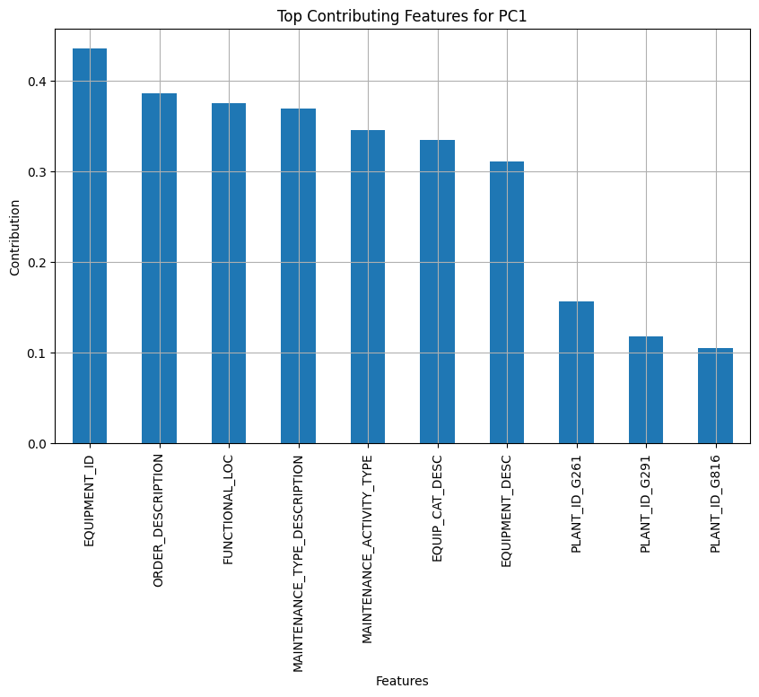

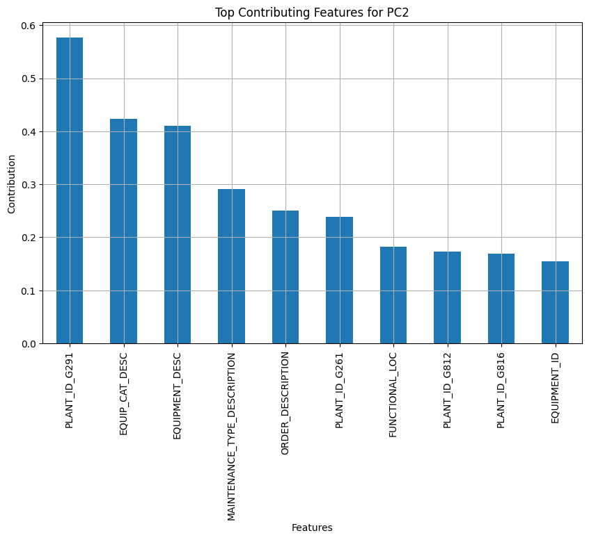

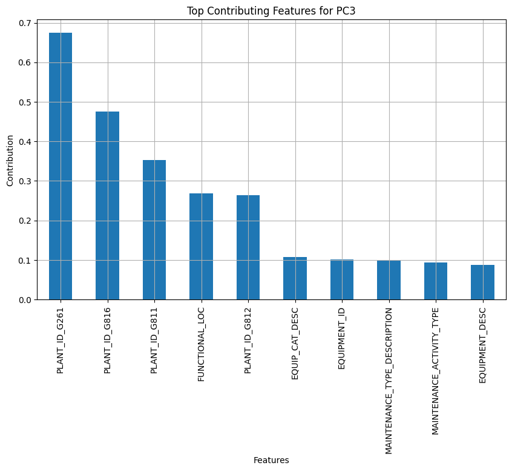

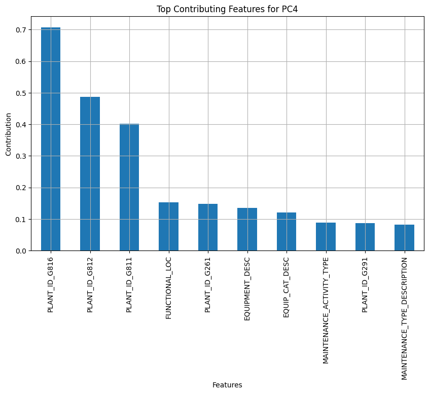

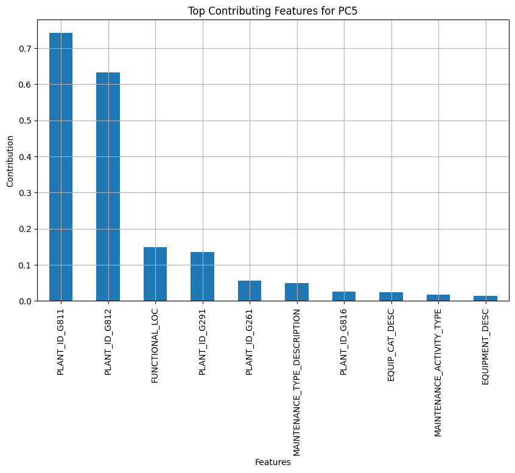

```python
for i in range(1, 6):  # Loop from PC1 to PC5
    pc_label = f'PC{i}'
    top_features = pca_components.loc[pc_label].abs().sort_values(ascending=False).head(10)  # Get top 10 features

    # Plot the top contributing features for the current principal component
    plt.figure(figsize=(10, 6))
    top_features.plot(kind='bar')
    plt.title(f'Top Contributing Features for {pc_label}')
    plt.xlabel('Features')
    plt.ylabel('Contribution')
    plt.grid(True)
    plt.show()
```

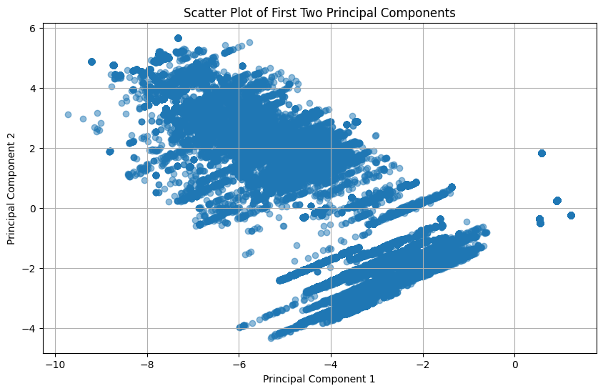

```python
plt.figure(figsize=(10, 6))
plt.scatter(X_reduced[:, 0], X_reduced[:, 1], alpha=0.5)
plt.xlabel('Principal Component 1')
plt.ylabel('Principal Component 2')
plt.title('Scatter Plot of First Two Principal Components')
plt.grid(True)
plt.show()
```

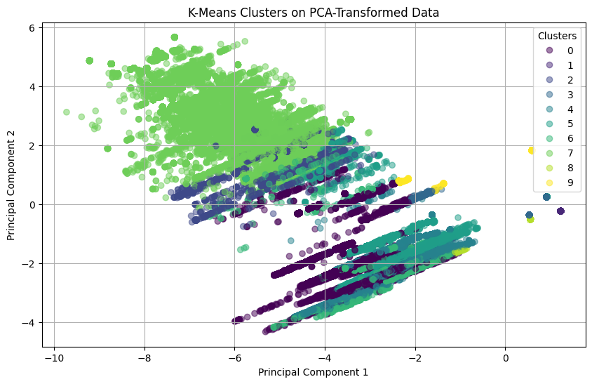

```python
plt.figure(figsize=(10, 6))
scatter = plt.scatter(X_reduced[:, 0], X_reduced[:, 1], c=labels, cmap='viridis', alpha=0.5)
plt.xlabel('Principal Component 1')
plt.ylabel('Principal Component 2')
plt.title('K-Means Clusters on PCA-Transformed Data')
plt.legend(*scatter.legend_elements(), title='Clusters')
plt.grid(True)
plt.show()
```

### Unplanned

```python
unplanned_df = master_df2[master_df2['MAINTENANCE_ACTIVITY_TYPE'] == 'Unplanned']
```

```python
unplanned_df.head()
```

|  | PLANT_ID | EXECUTION_START_DATE | EXECUTION_FINISH_DATE | ACTUAL_START_TIME | ACTUAL_FINISH_TIME | ACTUAL_WORK_IN_MINUTES | MAINTENANCE_PLAN | MAINTENANCE_ITEM | MAINTENANCE_ACTIVITY_TYPE | ORDER_DESCRIPTION | MAINTENANCE_TYPE_DESCRIPTION | FUNCTIONAL_LOC | EQUIPMENT_ID | EQUIPMENT_DESC | EQUIP_CAT_DESC | EQUIP_START_UP_DATE | EQUIP_VALID_FROM |
| --- | --- | --- | --- | --- | --- | --- | --- | --- | --- | --- | --- | --- | --- | --- | --- | --- | --- |
| 0 | G812 | 2024-05-04 | 2024-05-12 | 06:00:00.000 | 23:04:08.000 | 390.0 | Unknown | Unknown | Unplanned | L2 GEARBOX LEAK (SEE ATTACHED) | Corrective Maintenance Order | G812-PRD-L15-L03-L030-020 | 300126812.0 | FULL CAN CONVEYOR (FC41B) | Machines | 2020-04-22 | 2020-02-10 |
| 1 | G812 | 2022-09-13 | 2022-09-13 | 06:00:00.000 | 17:17:24.000 | 420.0 | Unknown | Unknown | Unplanned | LINE 3 CONVEYOR AT CAN CODER | Corrective Maintenance Order | G812-PRD-L15-L03-L030-020 | 300126812.0 | FULL CAN CONVEYOR (FC41B) | Machines | 2020-04-22 | 2020-02-10 |
| 2 | G812 | 2022-12-21 | 2022-12-21 | 07:00:00.000 | 07:00:00.000 | 30.0 | Unknown | Unknown | Unplanned | BROKEN CONVEYOR RAIL | Corrective Maintenance Order | G812-PRD-L15-L03-L030-020 | 300126812.0 | FULL CAN CONVEYOR (FC41B) | Machines | 2020-04-22 | 2020-02-10 |
| 3 | G812 | 2022-07-04 | 2022-07-04 | 06:00:00.000 | 06:00:00.000 | 60.0 | Unknown | Unknown | Unplanned | LINE 3 CONVEYOR | Corrective Maintenance Order | G812-PRD-L15-L03-L030-020 | 300126812.0 | FULL CAN CONVEYOR (FC41B) | Machines | 2020-04-22 | 2020-02-10 |
| 4 | G291 | 2023-03-15 | 2023-03-15 | 07:00:00.000 | 07:00:00.000 | 120.0 | Unknown | Unknown | Unplanned | REPLACED SONIC AIR BLOWER BELT | Corrective Maintenance Order | G291-PRD-P05 | 300001088.0 | TANK_STL_STOR_AIR | Machines | 2017-02-15 | 2023-12-11 |

```python
columns_to_drop = ['EXECUTION_START_DATE', 'EXECUTION_FINISH_DATE',
                   'ACTUAL_START_TIME', 'ACTUAL_FINISH_TIME', 'EQUIP_VALID_FROM',
                   'EQUIP_START_UP_DATE', 'MAINTENANCE_PLAN', 'MAINTENANCE_ITEM', 'ACTUAL_WORK_IN_MINUTES']
unplanned_df.drop(columns=columns_to_drop, inplace=True)
```

```python
# Apply one-hot encoding to 'PLANT_ID' column
unplanned_df_encoded = pd.get_dummies(unplanned_df, columns=['PLANT_ID'], drop_first=True)

# Identify non-numeric columns after one-hot encoding
non_numeric_cols = unplanned_df_encoded.select_dtypes(include=['object', 'category']).columns
print("Non-numeric columns:", non_numeric_cols)

# Apply LabelEncoder only if there are non-numeric columns
if len(non_numeric_cols) > 0:
    for col in non_numeric_cols:
        le = LabelEncoder()
        unplanned_df_encoded[col] = le.fit_transform(unplanned_df_encoded[col].astype(str))
else:
    print("No non-numeric columns to encode.")
```

```
Non-numeric columns: Index(['MAINTENANCE_ACTIVITY_TYPE', 'ORDER_DESCRIPTION',
       'MAINTENANCE_TYPE_DESCRIPTION', 'FUNCTIONAL_LOC', 'EQUIPMENT_ID',
       'EQUIPMENT_DESC', 'EQUIP_CAT_DESC'],
      dtype='object')
```

```python
# Convert DataFrame to NumPy array and standardize
X = unplanned_df_encoded.values
scaler = StandardScaler()
X_scaled = scaler.fit_transform(X)

# Reduce dimensionality
pca = PCA(n_components=5, random_state=42)
X_reduced = pca.fit_transform(X_scaled)

# Apply MiniBatch KMeans
mbk10 = MiniBatchKMeans(n_clusters=10, batch_size=10000, random_state=42)
mbk10.fit(X_reduced)
labels = mbk10.labels_

unplanned_df_encoded['Cluster'] = labels  # 'labels' should be the output from mbk10.labels_
```

```python
# Group data by clusters and calculate average feature values for cluster analysis
cluster_summary = unplanned_df_encoded.groupby('Cluster').mean()

# Display the summary of the clusters
print("Cluster Summary (Average Feature Values):")
print(cluster_summary)

# Check the size of each cluster
cluster_sizes = unplanned_df_encoded['Cluster'].value_counts()
print("\nCluster Sizes:")
print(cluster_sizes)

# Highlight key insights about clusters by printing top contributing features
for cluster in cluster_summary.index:
    print(f"\nCluster {cluster} Analysis:")
    print(cluster_summary.loc[cluster].sort_values(ascending=False).head(5))
```

```
Cluster Summary (Average Feature Values):
         MAINTENANCE_ACTIVITY_TYPE  ORDER_DESCRIPTION  \
Cluster
0                              0.0      114974.000000
1                              0.0       57759.089882
2                              0.0      114946.917215
3                              0.0       63407.537963
4                              0.0      114973.485403
5                              0.0       51847.692288
6                              0.0      114961.378275
7                              0.0      114958.589483
8                              0.0       61854.521744
9                              0.0       57007.711790

         MAINTENANCE_TYPE_DESCRIPTION  FUNCTIONAL_LOC  EQUIPMENT_ID  \
Cluster
0                            5.000000      648.000000   2715.000000
1                            2.941318      195.816392    870.188602
2                            4.996207      647.733630   2714.388188
3                            2.943452      293.077646   1034.590741
4                            4.999753      647.979882   2714.987691
5                            2.795845      592.126712   1384.613945
6                            4.998647      647.664534   2714.858418
7                            4.997466      647.950012   2714.593901
8                            2.816732      396.618555   1807.171361
9                            2.623794      582.153698   1875.857556

         EQUIPMENT_DESC  EQUIP_CAT_DESC  PLANT_ID_G261  PLANT_ID_G291  \
Cluster
0            739.000000        4.000000       1.000000       0.000000
1            738.999723        3.999931       0.461107       0.009434
2            739.000000        4.000000       0.000000       0.000000
3            380.338360        0.003571       0.104762       0.586772
4            739.000000        4.000000       0.000000       0.000000
5            738.982765        3.999884       0.000000       0.000000
6            739.000000        4.000000       0.000000       1.000000
7            738.995192        3.999935       0.000000       0.000000
8            738.987886        3.996583       0.000000       0.000000
9            376.956592        0.002251       0.000000       0.000000

```

[output cut: 91 more lines]

```
Cluster 8 Analysis:
ORDER_DESCRIPTION    61854.521744
EQUIPMENT_ID          1807.171361
EQUIPMENT_DESC         738.987886
FUNCTIONAL_LOC         396.618555
EQUIP_CAT_DESC           3.996583
Name: 8, dtype: float64

Cluster 9 Analysis:
ORDER_DESCRIPTION               57007.711790
EQUIPMENT_ID                     1875.857556
FUNCTIONAL_LOC                    582.153698
EQUIPMENT_DESC                    376.956592
MAINTENANCE_TYPE_DESCRIPTION        2.623794
Name: 9, dtype: float64
```

```python
# Explained variance ratio of each component
explained_variance = pca.explained_variance_ratio_
for i, var in enumerate(explained_variance):
    print(f'Principal Component {i+1}: {var:.4f} variance explained')
```

```
Principal Component 1: 0.3555 variance explained
Principal Component 2: 0.1487 variance explained
Principal Component 3: 0.1231 variance explained
Principal Component 4: 0.1005 variance explained
Principal Component 5: 0.0972 variance explained
```

```python
# PCA components
pca_components = pd.DataFrame(
    pca.components_,
    columns=MiniPCA_encoded.columns[:-1],
    index=[f'PC{i+1}' for i in range(pca.n_components_)]
)
print(pca_components)
```

```
     MAINTENANCE_ACTIVITY_TYPE  ORDER_DESCRIPTION  \
PC1                       -0.0           0.436362
PC2                       -0.0          -0.172432
PC3                       -0.0           0.072926
PC4                       -0.0           0.037867
PC5                        0.0           0.050561

     MAINTENANCE_TYPE_DESCRIPTION  FUNCTIONAL_LOC  EQUIPMENT_ID  \
PC1                      0.466613        0.398473      0.457147
PC2                     -0.141732       -0.281689     -0.233614
PC3                      0.053033       -0.018013      0.056661
PC4                      0.036730       -0.281963     -0.125763
PC5                      0.025387       -0.165470     -0.000313

     EQUIPMENT_DESC  EQUIP_CAT_DESC  PLANT_ID_G261  PLANT_ID_G291  \
PC1        0.286853        0.299843       0.116166       0.011965
PC2        0.532970        0.525865       0.323890      -0.365309
PC3       -0.343474       -0.331940       0.685932      -0.380339
PC4        0.018677       -0.000747       0.080410       0.613003
PC5       -0.093800       -0.085452       0.012767      -0.152736

     PLANT_ID_G811  PLANT_ID_G812  PLANT_ID_G816
PC1      -0.016125      -0.084114      -0.175879
PC2      -0.074276       0.033094      -0.103419
PC3      -0.261437      -0.244514      -0.129918
PC4      -0.382114      -0.009124      -0.610913
PC5       0.782665       0.016186      -0.563028
```

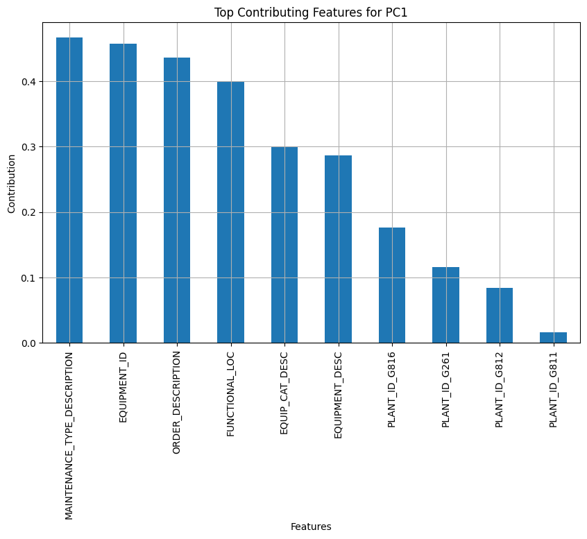

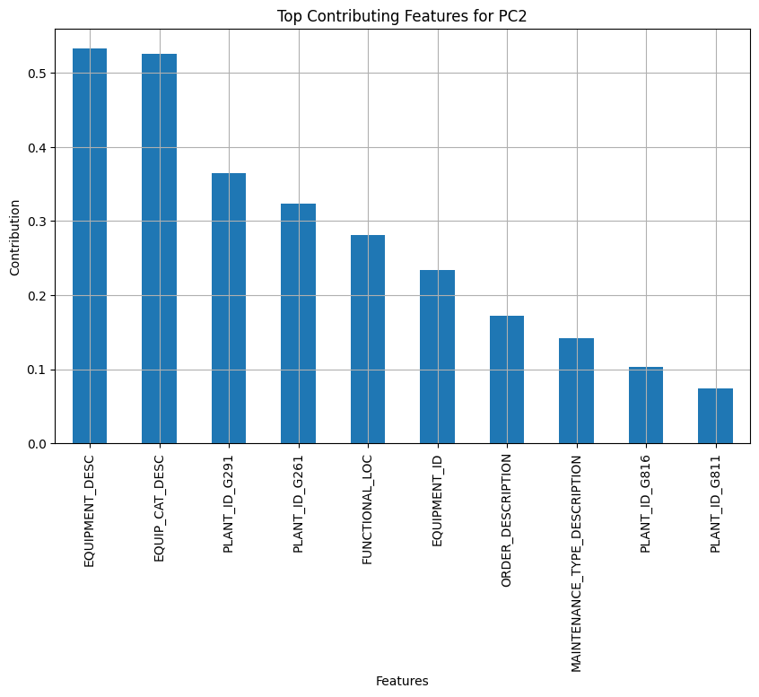

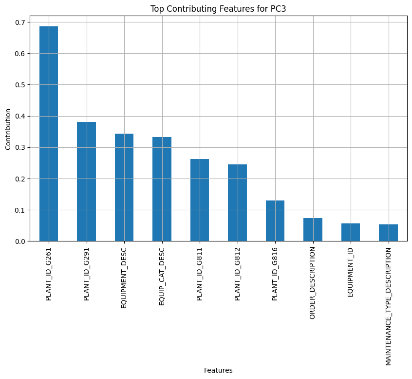

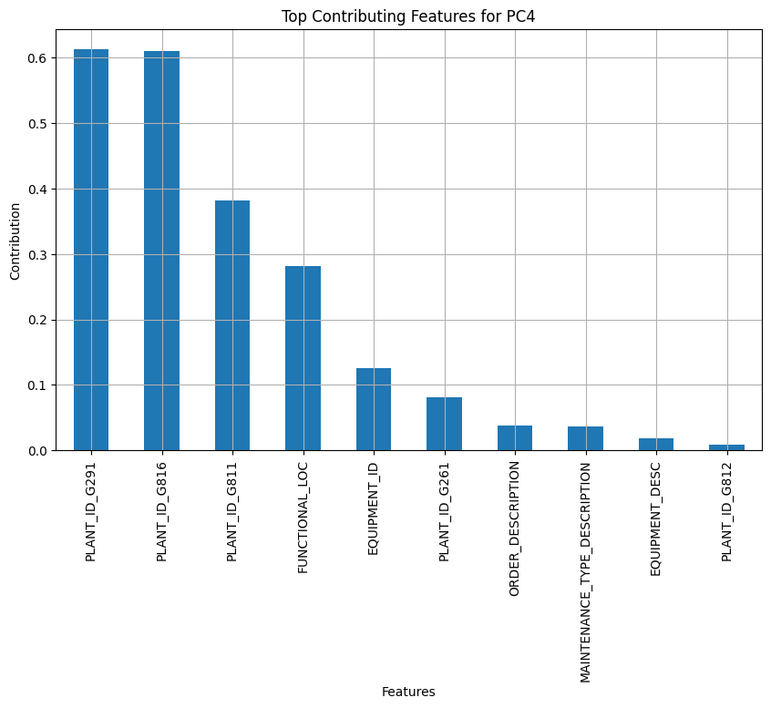

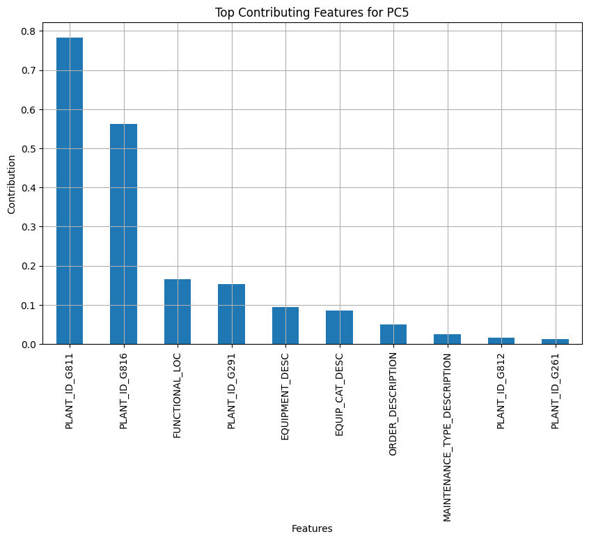

```python
for i in range(1, 6):  # Loop from PC1 to PC5
    pc_label = f'PC{i}'
    top_features = pca_components.loc[pc_label].abs().sort_values(ascending=False).head(10)  # Get top 10 features

    # Plot the top contributing features for the current principal component
    plt.figure(figsize=(10, 6))
    top_features.plot(kind='bar')
    plt.title(f'Top Contributing Features for {pc_label}')
    plt.xlabel('Features')
    plt.ylabel('Contribution')
    plt.grid(True)
    plt.show()
```

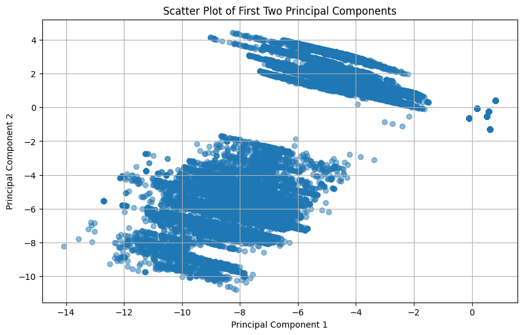

```python
plt.figure(figsize=(10, 6))
plt.scatter(X_reduced[:, 0], X_reduced[:, 1], alpha=0.5)
plt.xlabel('Principal Component 1')
plt.ylabel('Principal Component 2')
plt.title('Scatter Plot of First Two Principal Components')
plt.grid(True)
plt.show()
```

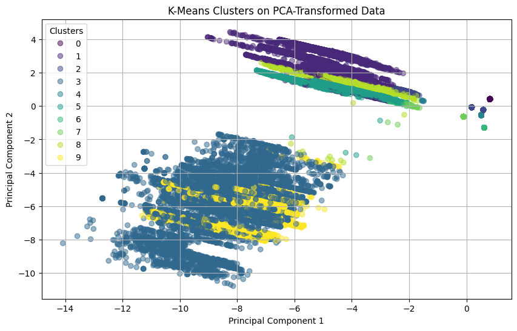

```python
plt.figure(figsize=(10, 6))
scatter = plt.scatter(X_reduced[:, 0], X_reduced[:, 1], c=labels, cmap='viridis', alpha=0.5)
plt.xlabel('Principal Component 1')
plt.ylabel('Principal Component 2')
plt.title('K-Means Clusters on PCA-Transformed Data')
plt.legend(*scatter.legend_elements(), title='Clusters')
plt.grid(True)
plt.show()
```

### Planned

```python
planned_df = master_df2[master_df2['MAINTENANCE_ACTIVITY_TYPE'] == 'Planned']
```

```python
columns_to_drop = ['EXECUTION_START_DATE', 'EXECUTION_FINISH_DATE',
                   'ACTUAL_START_TIME', 'ACTUAL_FINISH_TIME', 'EQUIP_VALID_FROM',
                   'EQUIP_START_UP_DATE', 'MAINTENANCE_PLAN', 'MAINTENANCE_ITEM', 'ACTUAL_WORK_IN_MINUTES']
planned_df.drop(columns=columns_to_drop, inplace=True)
```

```python
# Apply one-hot encoding to 'PLANT_ID' column
planned_df_encoded = pd.get_dummies(planned_df, columns=['PLANT_ID'], drop_first=True)

# Identify non-numeric columns after one-hot encoding
non_numeric_cols = planned_df_encoded.select_dtypes(include=['object', 'category']).columns
print("Non-numeric columns:", non_numeric_cols)

# Apply LabelEncoder only if there are non-numeric columns
if len(non_numeric_cols) > 0:
    for col in non_numeric_cols:
        le = LabelEncoder()
        planned_df_encoded[col] = le.fit_transform(planned_df_encoded[col].astype(str))
else:
    print("No non-numeric columns to encode.")
```

```
Non-numeric columns: Index(['MAINTENANCE_ACTIVITY_TYPE', 'ORDER_DESCRIPTION',
       'MAINTENANCE_TYPE_DESCRIPTION', 'FUNCTIONAL_LOC', 'EQUIPMENT_ID',
       'EQUIPMENT_DESC', 'EQUIP_CAT_DESC'],
      dtype='object')
```

```python
# Convert DataFrame to NumPy array and standardize
X = planned_df_encoded.values
scaler = StandardScaler()
X_scaled = scaler.fit_transform(X)

# Reduce dimensionality
pca = PCA(n_components=5, random_state=42)
X_reduced = pca.fit_transform(X_scaled)

# Apply MiniBatch KMeans
mbk10 = MiniBatchKMeans(n_clusters=10, batch_size=10000, random_state=42)
mbk10.fit(X_reduced)
labels = mbk10.labels_

planned_df_encoded['Cluster'] = labels  # 'labels' should be the output from mbk10.labels_
```

```python
# Group data by clusters and calculate average feature values for cluster analysis
cluster_summary = planned_df_encoded.groupby('Cluster').mean()

# Display the summary of the clusters
print("Cluster Summary (Average Feature Values):")
print(cluster_summary)

# Check the size of each cluster
cluster_sizes = planned_df_encoded['Cluster'].value_counts()
print("\nCluster Sizes:")
print(cluster_sizes)

# Highlight key insights about clusters by printing top contributing features
for cluster in cluster_summary.index:
    print(f"\nCluster {cluster} Analysis:")
    print(cluster_summary.loc[cluster].sort_values(ascending=False).head(5))
```

```
Cluster Summary (Average Feature Values):
         MAINTENANCE_ACTIVITY_TYPE  ORDER_DESCRIPTION  \
Cluster
0                              0.0        3167.470301
1                              0.0        2136.610907
2                              0.0        1035.078382
3                              0.0        3435.721904
4                              0.0        1556.731411
5                              0.0        2001.406748
6                              0.0        2881.286966
7                              0.0        1677.325552
8                              0.0        3165.077012
9                              0.0        2942.666012

         MAINTENANCE_TYPE_DESCRIPTION  FUNCTIONAL_LOC  EQUIPMENT_ID  \
Cluster
0                            1.000000      126.576064    626.318085
1                            1.000000      229.918019    172.607502
2                            1.000000      482.237796    958.796932
3                            0.999761      232.895654    124.994190
4                            1.000000      411.990057    693.628310
5                            0.998650      362.779509   1159.993620
6                            0.999951       48.032399    408.854744
7                            1.000000      114.658459    589.844975
8                            1.000000      476.665812    986.242504
9                            1.000000      457.635446   1189.893718

         EQUIPMENT_DESC  EQUIP_CAT_DESC  PLANT_ID_G261  PLANT_ID_G291  \
Cluster
0            381.000000        4.000000       1.000000       0.000000
1            180.250404        0.000264       0.000000       0.999677
2            381.000000        4.000000       0.000837       0.000000
3            274.297676        0.010984       0.000000       0.998329
4            342.059514        3.416455       0.000000       0.000000
5            340.117178        3.314847       0.000000       0.000000
6            378.670146        3.953124       0.009848       0.101285
7            381.000000        4.000000       0.992340       0.000000
8            380.986930        3.997822       0.000000       0.000000
9            140.505889        0.005048       0.000000       0.000000

```

[output cut: 91 more lines]

```
Cluster 8 Analysis:
ORDER_DESCRIPTION    3165.077012
EQUIPMENT_ID          986.242504
FUNCTIONAL_LOC        476.665812
EQUIPMENT_DESC        380.986930
EQUIP_CAT_DESC          3.997822
Name: 8, dtype: float64

Cluster 9 Analysis:
ORDER_DESCRIPTION               2942.666012
EQUIPMENT_ID                    1189.893718
FUNCTIONAL_LOC                   457.635446
EQUIPMENT_DESC                   140.505889
MAINTENANCE_TYPE_DESCRIPTION       1.000000
Name: 9, dtype: float64
```

```python
# Explained variance ratio of each component
explained_variance = pca.explained_variance_ratio_
for i, var in enumerate(explained_variance):
    print(f'Principal Component {i+1}: {var:.4f} variance explained')
```

```
Principal Component 1: 0.3066 variance explained
Principal Component 2: 0.1962 variance explained
Principal Component 3: 0.1308 variance explained
Principal Component 4: 0.1041 variance explained
Principal Component 5: 0.0904 variance explained
```

```python
# PCA components
pca_components = pd.DataFrame(
    pca.components_,
    columns=MiniPCA_encoded.columns[:-1],
    index=[f'PC{i+1}' for i in range(pca.n_components_)]
)
print(pca_components)
```

```
     MAINTENANCE_ACTIVITY_TYPE  ORDER_DESCRIPTION  \
PC1                        0.0           0.084561
PC2                       -0.0          -0.126939
PC3                       -0.0          -0.580497
PC4                        0.0          -0.117644
PC5                       -0.0          -0.062309

     MAINTENANCE_TYPE_DESCRIPTION  FUNCTIONAL_LOC  EQUIPMENT_ID  \
PC1                      0.004639       -0.217157     -0.432433
PC2                     -0.004343        0.580426      0.224200
PC3                      0.004498        0.002383     -0.093679
PC4                     -0.202780       -0.096786      0.233784
PC5                      0.977167       -0.015132      0.062423

     EQUIPMENT_DESC  EQUIP_CAT_DESC  PLANT_ID_G261  PLANT_ID_G291  \
PC1       -0.404066       -0.472073      -0.121593       0.497906
PC2       -0.289341       -0.261440      -0.506922       0.134532
PC3       -0.026100        0.012375       0.001389      -0.043452
PC4       -0.118215       -0.083256       0.043149       0.014075
PC5       -0.041103       -0.026692       0.039352       0.000140

     PLANT_ID_G811  PLANT_ID_G812  PLANT_ID_G816
PC1      -0.127382      -0.154909      -0.263878
PC2       0.108254       0.183604       0.352335
PC3       0.032265       0.640157      -0.490566
PC4       0.843310      -0.299133      -0.239581
PC5       0.159202      -0.084274      -0.027191
```

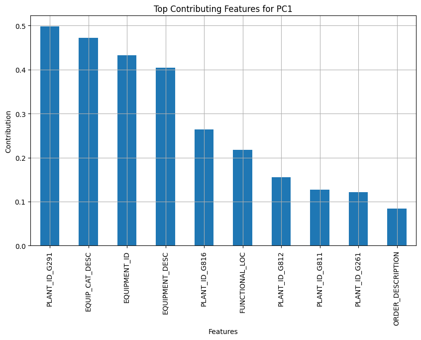

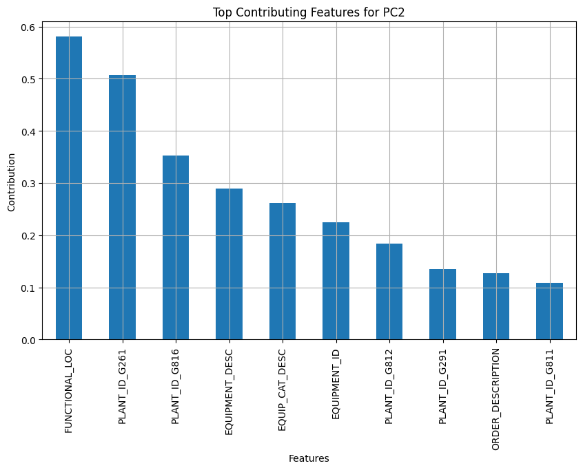

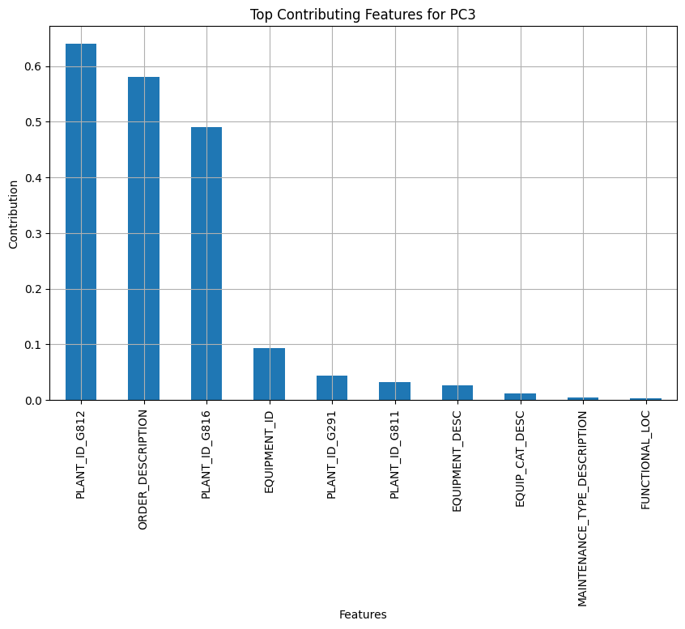

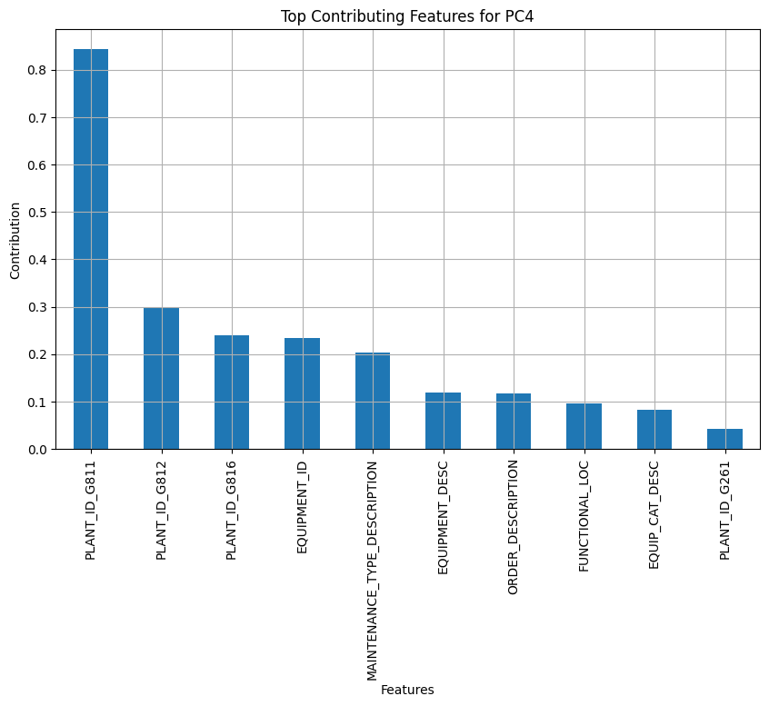

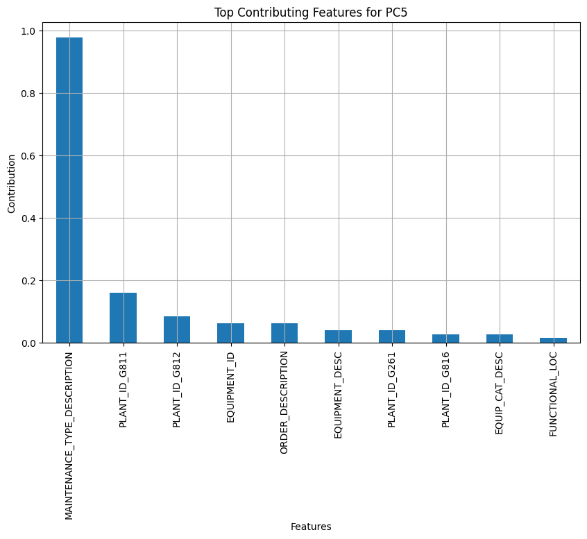

```python
for i in range(1, 6):  # Loop from PC1 to PC5
    pc_label = f'PC{i}'
    top_features = pca_components.loc[pc_label].abs().sort_values(ascending=False).head(10)  # Get top 10 features

    # Plot the top contributing features for the current principal component
    plt.figure(figsize=(10, 6))
    top_features.plot(kind='bar')
    plt.title(f'Top Contributing Features for {pc_label}')
    plt.xlabel('Features')
    plt.ylabel('Contribution')
    plt.grid(True)
    plt.show()
```

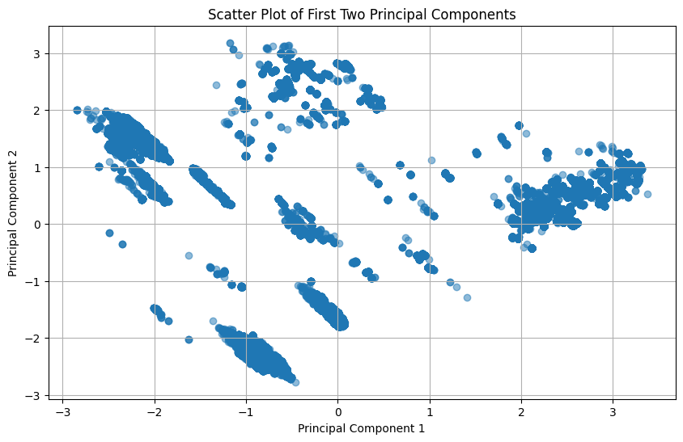

```python
plt.figure(figsize=(10, 6))
plt.scatter(X_reduced[:, 0], X_reduced[:, 1], alpha=0.5)
plt.xlabel('Principal Component 1')
plt.ylabel('Principal Component 2')
plt.title('Scatter Plot of First Two Principal Components')
plt.grid(True)
plt.show()
```

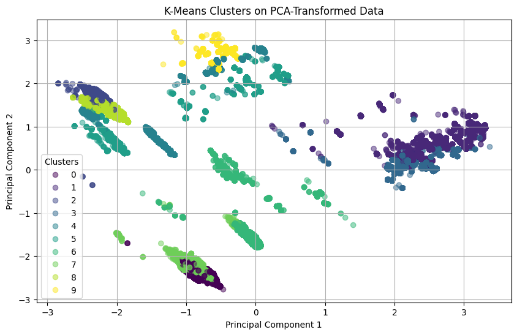

```python
plt.figure(figsize=(10, 6))
scatter = plt.scatter(X_reduced[:, 0], X_reduced[:, 1], c=labels, cmap='viridis', alpha=0.5)
plt.xlabel('Principal Component 1')
plt.ylabel('Principal Component 2')
plt.title('K-Means Clusters on PCA-Transformed Data')
plt.legend(*scatter.legend_elements(), title='Clusters')
plt.grid(True)
plt.show()
```

### PCA / CLUSTERING RESULTS

Conversely, the **Planned Maintenance** section presented different patterns. Clusters associated with planned maintenance often featured equipment with consistent maintenance schedules and showed lower incidences of sudden failures. These clusters revealed that plants that followed structured maintenance plans were more likely to exhibit steady performance and reduced downtime. Features like **EQUIP_CAT_DESC** and specific **PLANT_ID** identifiers contributed significantly to these clusters, suggesting that certain plants may have more reliable operational practices and better adherence to maintenance protocols. This distinction implies that proactive maintenance scheduling contributes to better-controlled operational environments and fewer disruptions.

**Patterns and Main Differences**:

**Common Patterns**: Across all sections, equipment-related features (**EQUIPMENT_ID**, **FUNCTIONAL_LOC**) consistently appeared as significant contributors, underscoring the central role of machine types in maintenance outcomes. This highlights that machine-specific data is vital for understanding both planned and unplanned maintenance dynamics.

**Differences**:

**Comprehensive Insights**:

For plants or clusters prone to unplanned maintenance, targeted interventions, such as enhanced monitoring systems or upgrades to older equipment, could reduce downtime. On the other hand, planned maintenance clusters highlight the benefits of structured preventive practices and serve as a model for achieving consistency across all plants.

### Planned Association Rule Mining

```python
# Remove rows with 'Unknown' in any column
planned_df_no_unknown = planned_df[~planned_df.apply(lambda row: row.astype(str).str.contains('Unknown')).any(axis=1)]

# Create transactions for association rule mining, ensuring all elements are strings
transactions = planned_df_no_unknown[['FUNCTIONAL_LOC', 'ORDER_DESCRIPTION', 'MAINTENANCE_ACTIVITY_TYPE']].astype(str).values.tolist()

# Encode transactions and apply apriori
te = TransactionEncoder()
df = pd.DataFrame(te.fit_transform(transactions), columns=te.columns_)
frequent_itemsets = apriori(df, min_support=0.01, use_colnames=True)

# Generate and display rules
rules = association_rules(frequent_itemsets, metric="lift", min_threshold=1)
print(rules)
```

```
                                           antecedents  \
0                                            (Planned)
1                (CHECK CHILLER FOR AMMONIA LEAK WKLY)
2                   (E-STOP FOR ELEC MONTHLY SHUTDOWN)
3                                            (Planned)
4                                            (Planned)
..                                                 ...
111  (MONTHLY FULL CAN CONVEYOR MECH SHUTDOWN, G816...
112                   (Planned, G816-PRD-L15-L01-L030)
113          (MONTHLY FULL CAN CONVEYOR MECH SHUTDOWN)
114                                          (Planned)
115                            (G816-PRD-L15-L01-L030)

                                           consequents  antecedent support  \
0                (CHECK CHILLER FOR AMMONIA LEAK WKLY)            1.000000
```

[output cut: 38 more lines]